# A50 Coursework

Hu Tang

November 12, 2018

**The contents of this work and the associated code are my own unless otherwise stated**

# Load libraries and import data:

```r
require(dplyr)
```

```r
require(ggplot2)
require(ggcorrplot)
require(ROCR)
require(caret)
require(data.table)
require(grid)
require(gridExtra)
require(gtable)
require(class)
require(randomForest)
require(e1071)
require(caret)
require(leaps)
load("C:/Users/TIGER/Desktop/3rd Year/Data Science/druguse.RData")

set.seed(123)
```

# Question 1

## 1.1(a)

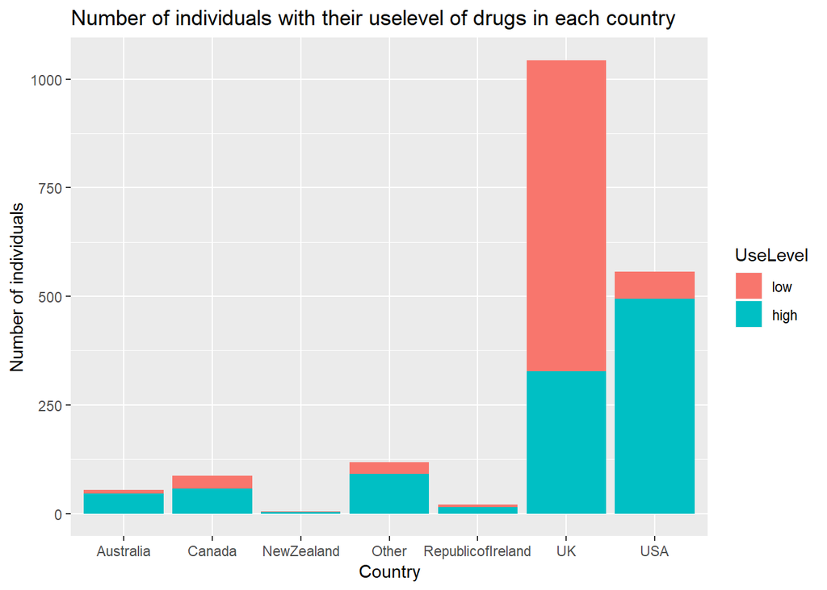

```r
ggplot(druguse, aes(country)) +
  geom_bar(aes(fill = UseLevel)) +
  labs(x = "Country", y = "Number of individuals", title = "Number of individuals with their uselevel of drugs in each country")
```

The plot shows that apart from UK, which has higher proportion of individuals that have low use level, the other countries have higher proportion of individuals that have high use level.

## 1.1(b)

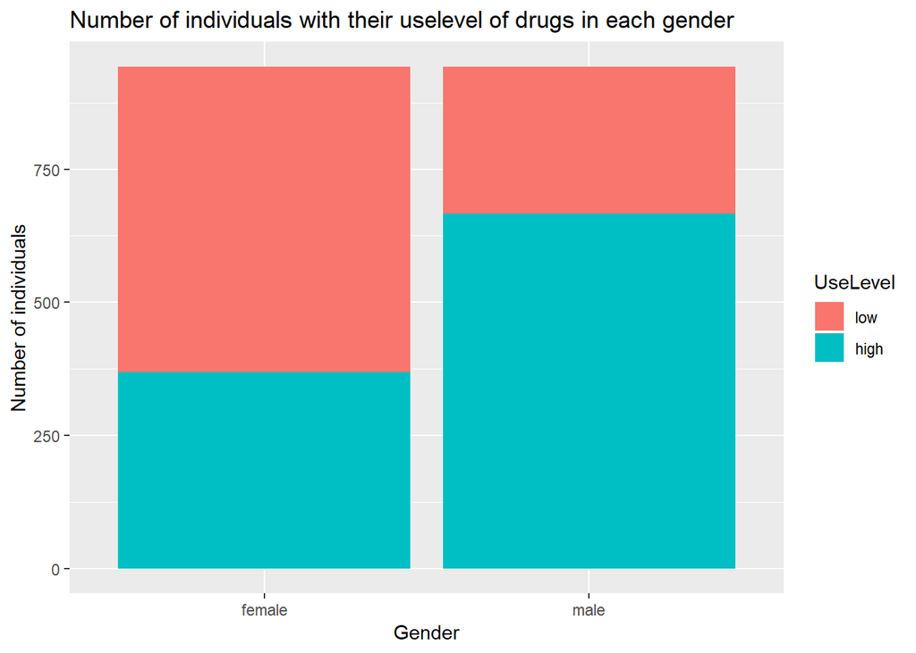

```r
ggplot(druguse, aes(gender)) +
  geom_bar(aes(fill = UseLevel)) +
  labs(x = "Gender", y = "Number of individuals", title = "Number of individuals with their uselevel of drugs in each gender")
```

The plot illustrates that male are more likely to have higher use level of drugs than female.

## data cleaning

We change some feature of druguse to numerical variables for future EDA and modeling purposes.

```r
newdruguse <- druguse
newdruguse$gender <- as.numeric(factor(druguse$gender))
newdruguse$agegroup <- as.numeric(factor(druguse$agegroup))
newdruguse$country <- as.numeric(factor(druguse$country))
newdruguse$ethnicity <- as.numeric(factor(druguse$ethnicity))
newdruguse$any <- as.numeric(factor(druguse$any))
newdruguse$UseLevel <- as.numeric(factor(druguse$UseLevel))
```

## 1.2

### 1.2.1 Pearson Correlation Heatmap

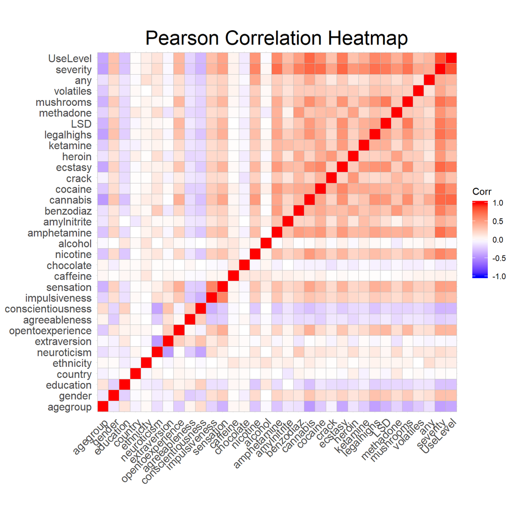

```r
corr <- cor(newdruguse)
ggcorrplot(corr) +
  labs(x = "outcome",
       y = "predictor") +
  ggtitle("Pearson Correlation Heatmap") +
  theme(plot.title = element_text(hjust=0.5,size=22))
```

The plot shows that severity and use level both have strong positive correlations with the illegal drugs(since both severity and uselevel are constructed from them) and nicotine, sensation, impulsiveness, opentoexperience and gender. Also, strong negative correlations with conscientiousness, agreeableness, education and agegroup. Nearly no correlation with alcohol, extraversion and country.

### 1.2.2 Scatter plot of conscientiousness and opentoexperience of individuals

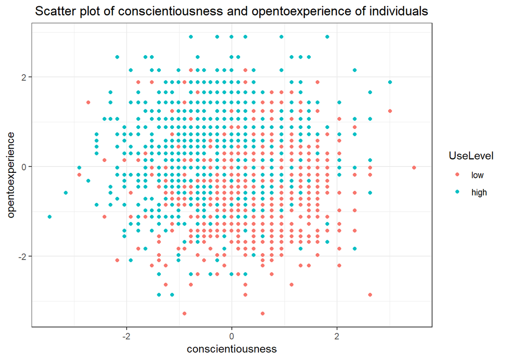

```r
ggplot(druguse, aes(x = conscientiousness, y = opentoexperience)) +
  geom_point(aes(color = UseLevel), size = 1.5) +
  theme_bw() +
  labs(title = "Scatter plot of conscientiousness and opentoexperience of individuals")+
  theme(plot.title = element_text(hjust = 0.5))
```

We can see that there is a boundary that seperate low and high use levels: opentoexperience and use level has a strong positive correlation, while conscientiousness and use level has a strong negative correlation.

### 1.2.3 Opentoexperience of individuals, sorted by Uselevel

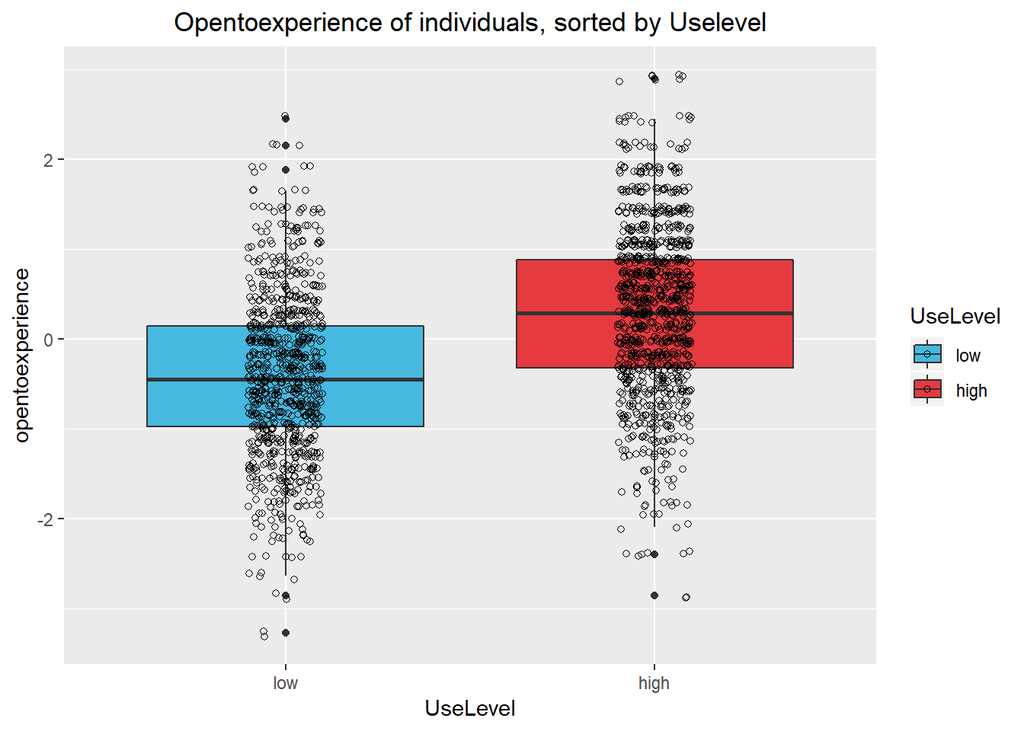

```r
ggplot(druguse, aes(x = UseLevel, y = opentoexperience, fill = UseLevel)) +
  geom_boxplot() +
  geom_jitter(shape=1, position=position_jitter(0.1)) +
  labs(title = "Opentoexperience of individuals, sorted by Uselevel") +
  theme(plot.title = element_text(hjust = 0.5)) +
  scale_fill_manual(values = c("#47b8e0","#E53A40"))
```

The plot illustrates that use level and opentoexpeirence has a strong positive correlation.

### 1.2.4 Number of individuals in each Uselevel, sorted by agegroup and gender

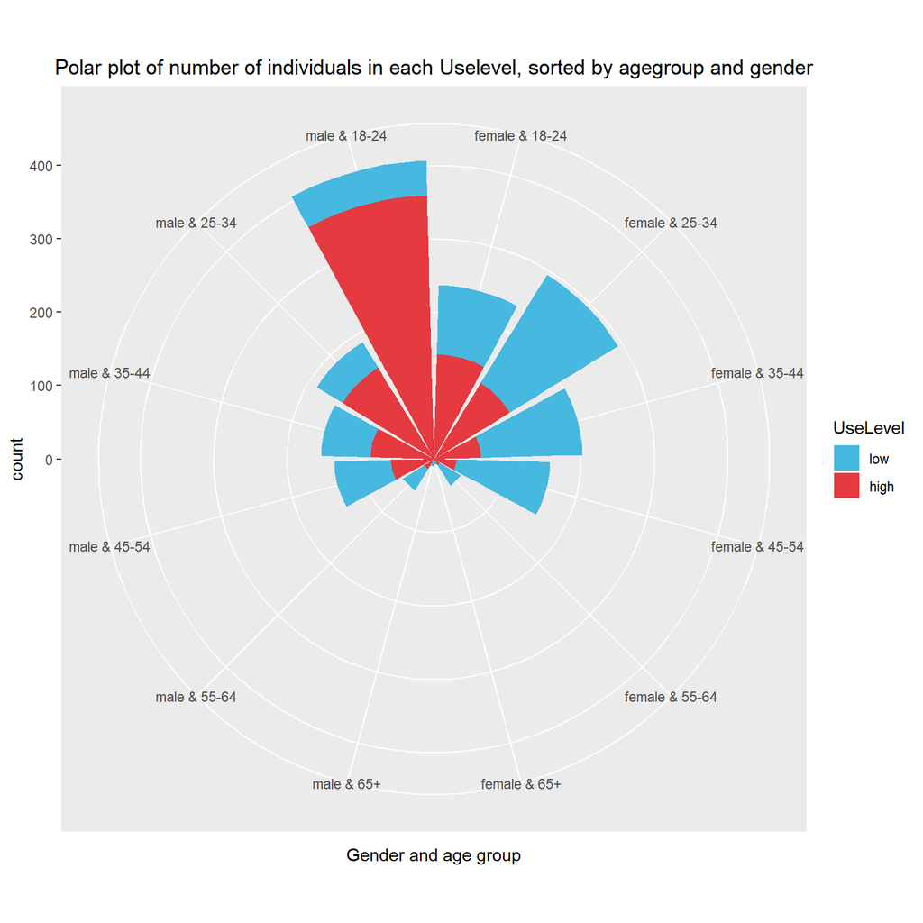

```r
druguse_plus <- druguse
druguse_plus$gender_age <- paste(druguse_plus$gender,"&",druguse_plus$agegroup)
druguse_plus$gender_age <- factor(druguse_plus$gender_age, levels = c("female & 18-24", "female & 25-34", "female & 35-44", "female & 45-54", "female & 55-64", "female & 65+", "male & 65+", "male & 55-64", "male & 45-54", "male & 35-44", "male & 25-34", "male & 18-24"))
ggplot(druguse_plus, aes(x = gender_age, fill = UseLevel)) +
    geom_bar(alpha = 1) +
    coord_polar(theta = "x", direction=1 )+
    labs(x = "Gender and age group", y = "count", title = "Polar plot of number of individuals in each Uselevel, sorted by agegroup and gender")+
    scale_fill_manual(values = c("#47b8e0","#E53A40"))+
    theme(plot.title = element_text(hjust = 0.5))
```

The polar plot shows that younger individuals are more likely to have a high use level, and female tends to have a low use level comparing to male.

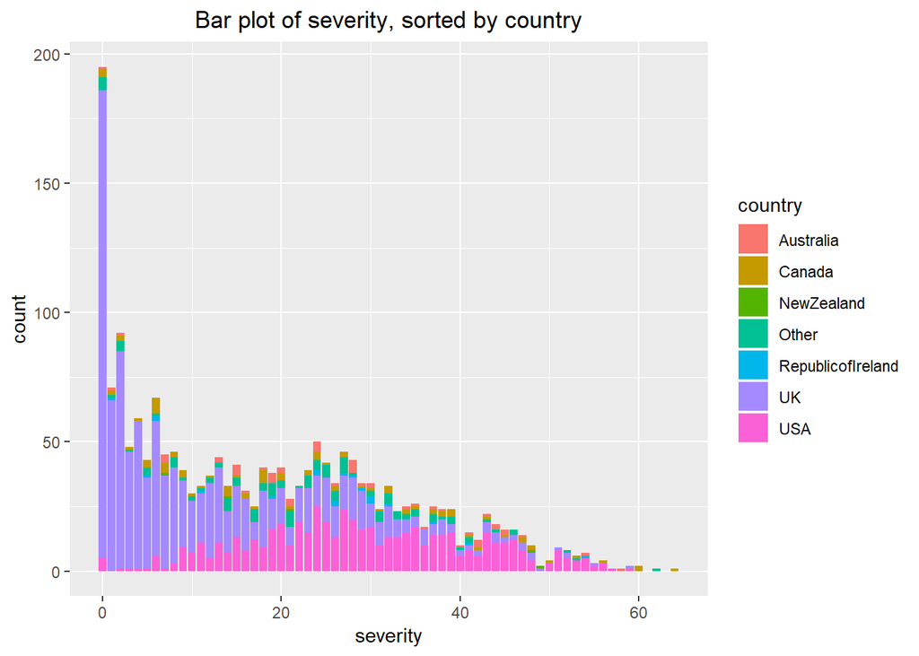

```r
ggplot(druguse_plus, aes(x = severity, fill = country)) +
    geom_bar(alpha = 1) +
    theme(plot.title = element_text(hjust = 0.5)) +
    labs(title = "Bar plot of severity, sorted by country")
```

From the plot, we can see that individuals in UK generally has lower severity than individuals in other countries. However individuals in USA has higher severity than individuals in other countries.

### 1.2.6 Violin plot of severity, sorted by agegroup

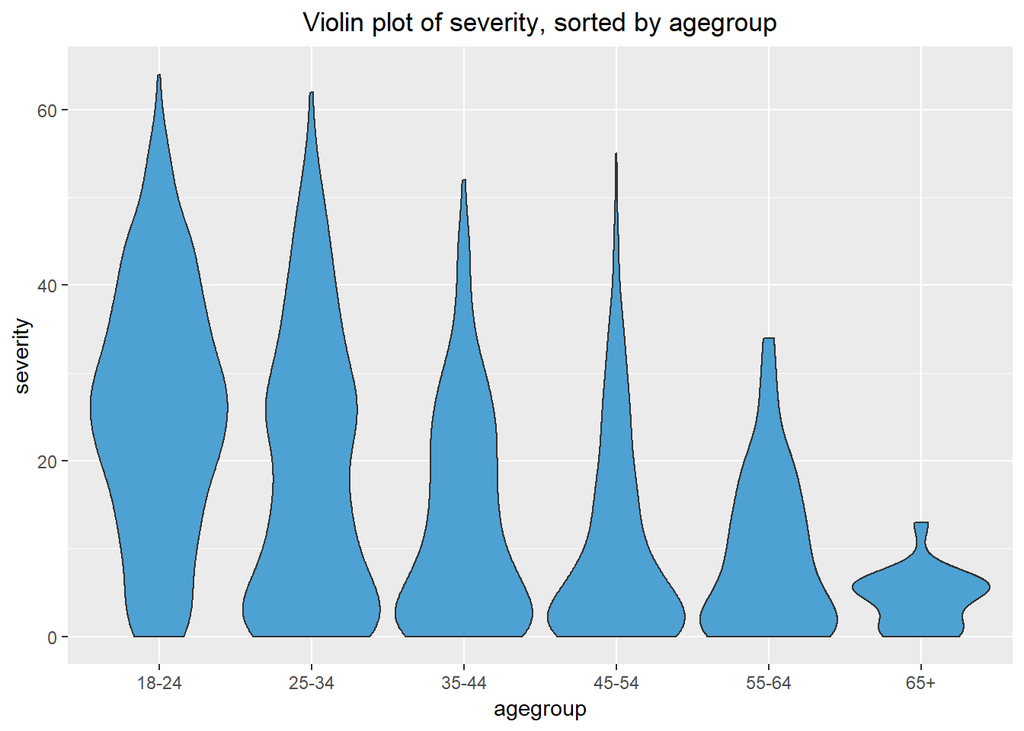

```r
ggplot(druguse, aes(x =  agegroup, y = severity)) +
    geom_violin(fill = "#4ea1d3", scale = "width", aes(group = agegroup)) +
    labs(title = "Violin plot of severity, sorted by agegroup") +
    theme(plot.title = element_text(hjust = 0.5))
```

The plot tells us that younger people are more likely have higer severity. There is a strong negative correlation between severity and agegroup.

# Question 2

## 2.1

```r
new2druguse <- druguse[,c(1:16,33)]
train <- new2druguse[1:1400,]
validation <- new2druguse[1401:1885,]
model <- glm(UseLevel ~., family = binomial(link = 'logit'), data = train)
levels(train$UseLevel)
```

```
## [1] "low"  "high"
```

```r
summary(model)
```

```
##
## Call:
## glm(formula = UseLevel ~ ., family = binomial(link = "logit"),
##     data = train)
##
## Deviance Residuals:
##     Min       1Q   Median       3Q      Max
## -3.3880  -0.3865   0.1221   0.4357   2.8387
##
## Coefficients:
##                              Estimate Std. Error z value Pr(>|z|)
## (Intercept)                  -0.84266    1.13278  -0.744  0.45694
## agegroup25-34                 0.26901    0.24571   1.095  0.27359
## agegroup35-44                -0.17433    0.25605  -0.681  0.49598
## agegroup45-54                -0.65564    0.27445  -2.389  0.01690 *
## agegroup55-64                -0.98729    0.40893  -2.414  0.01576 *
## agegroup65+                 -16.81790  502.60332  -0.033  0.97331
## gendermale                    0.93652    0.18530   5.054 4.33e-07 ***
## education                    -0.25677    0.09947  -2.581  0.00984 **
## countryCanada                -0.81196    0.62733  -1.294  0.19556
## countryNewZealand            -0.43152    1.48226  -0.291  0.77096
## countryOther                 -1.00621    0.61469  -1.637  0.10164
## countryRepublicofIreland     -1.61533    0.95965  -1.683  0.09233 .
## countryUK                    -2.10637    0.51748  -4.070 4.69e-05 ***
## countryUSA                    0.07998    0.54650   0.146  0.88364
## ethnicityBlack               -0.46926    1.21613  -0.386  0.69960
## ethnicityMixed-Black/Asian   13.17401 2399.54491   0.005  0.99562
## ethnicityMixed-White/Asian    1.34439    1.34799   0.997  0.31860
## ethnicityMixed-White/Black    0.61315    1.13218   0.542  0.58812
## ethnicityOther                0.41618    0.97087   0.429  0.66816
## ethnicityWhite                1.06211    0.85269   1.246  0.21291
## neuroticism                  -0.06843    0.10697  -0.640  0.52234
## extraversion                 -0.13871    0.11164  -1.242  0.21406
## opentoexperience              0.56631    0.10678   5.304 1.14e-07 ***
## agreeableness                -0.09095    0.09740  -0.934  0.35041
## conscientiousness            -0.31084    0.10487  -2.964  0.00304 **
## impulsiveness                -0.01198    0.11249  -0.107  0.91517
## sensation                     0.72043    0.13213   5.453 4.96e-08 ***
## caffeine                      0.07957    0.08073   0.986  0.32431
## chocolate                    -0.09428    0.08338  -1.131  0.25815
## nicotine                      0.48841    0.03924  12.447  < 2e-16 ***
## alcohol                      -0.06487    0.06890  -0.942  0.34642
## ---
## Signif. codes:  0 '***' 0.001 '**' 0.01 '*' 0.05 '.' 0.1 ' ' 1
##
## (Dispersion parameter for binomial family taken to be 1)
##
##     Null deviance: 1923.39  on 1399  degrees of freedom
## Residual deviance:  894.64  on 1369  degrees of freedom
## AIC: 956.64
##
## Number of Fisher Scoring iterations: 15
```

Note that higher value in nicotine and chocolate means higher frequency of consumpiton, also the levels of use level is low and high repectively.

The estimate coefficient of nicotine is 0.49 which is positive, hence we conclude that given other predictors, smokers are more likely to have a high use level.

Also, the estimate coefficient of chocolate is -0.09 which is negative. Hence, given other predictors, chocolate eaters are less likely to have a high use level.

## 2.2

```r
predictdata <- predict(model, newdata = validation[,1:16], type = "response")
mypreds <- ifelse(predictdata > 0.5, 1, 0)
validation$UseLevel <- ifelse(validation$UseLevel == "high", 1, 0)
#create table
TP <- sum(mypreds==1 & validation$UseLevel =="1")
FP <- sum(mypreds==1 & validation$UseLevel =="0")
TN <- sum(mypreds==0 & validation$UseLevel =="0")
FN <- sum(mypreds==0 & validation$UseLevel =="1") #Here 0 represents low, 1 represents high
tablematrix <- matrix(data = c(TP,FN,FP,TN), nrow = 2, ncol = 2,
                      dimnames = list(c("high","low"),c("high","low")))
names(dimnames(tablematrix)) <- c("predicted","observed")
tablematrix
```

```
##          observed
## predicted high low
##      high  223  33
##      low    35 194
```

## 2.3

Accuracy

```r
accuracy <- (TP+TN)/(TP+TN+FN+FP) #implement the accuracy formula
accuracy
```

```
## [1] 0.8597938
```

ROC curve

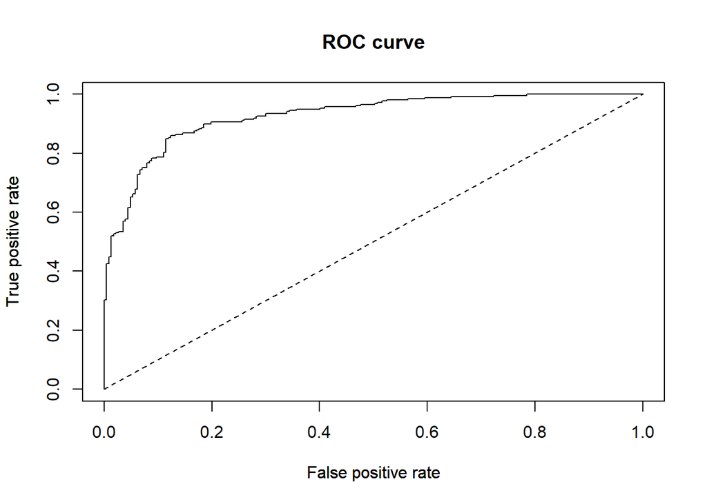

```r
pr <- prediction(predictdata, validation$UseLevel)
roc <- performance(pr, measure = "tpr", x.measure = "fpr")
plot(roc)
par(new=TRUE)
lines(0:1, 0:1, type="l",lty =2)
title("ROC curve", xlab = "False positive rate", ylab = "True positive rate")
```

```r
par(new=FALSE)
```

The ROC curve is high above $y=x$, which means it is a good classfier.

Compute AUC

```r
auc <- performance(pr, measure = "auc")
auc <- auc@y.values[[1]]
auc
```

```
## [1] 0.926903
```

The high AUC value also shows that it is a good classfier.

# 2.4

```r
#Randomly shuffle the data
new2druguse<- new2druguse[sample(nrow(new2druguse)),]
new2druguse$UseLevel <- ifelse(new2druguse$UseLevel == "high", 1, 0)

folds <- cut(seq(1,nrow(new2druguse)),breaks=10,labels=FALSE) #Create 10 equally size folds


accuracy_list <- c() #Create a list that save the accuracy of each time.

#Perform 10 fold cross validation

for(i in 1:10){
  #Segement data by fold
  testIndexes <- which(folds==i,arr.ind=TRUE)
  testData <- new2druguse[testIndexes, ] #assign testdata
  trainData <- new2druguse[-testIndexes, ] #assign traindata
  #implement model on traindata and predict on testdata
  model <- glm(UseLevel ~., family = binomial(link = 'logit'), data = trainData)
  predictdata <- predict(model, newdata = testData[,1:16], type = "response")
  mypreds <- ifelse(predictdata > 0.5, 1, 0)
  #Compute the accuracy of each time
  TP <- sum(mypreds==1 & testData$UseLevel =="1")
  TN <- sum(mypreds==0 & testData$UseLevel =="0")
  accuracy <- (TP+TN)/nrow(testData)
  accuracy_list <- c(accuracy_list, accuracy) #Append the new accuracy to the others.
}
avg_accuracy <- sum(accuracy_list)/10 #Average accuracy is calculated.
avg_accuracy
```

```
## [1] 0.8561972
```

Create table for the accuracy_list and average accuracy

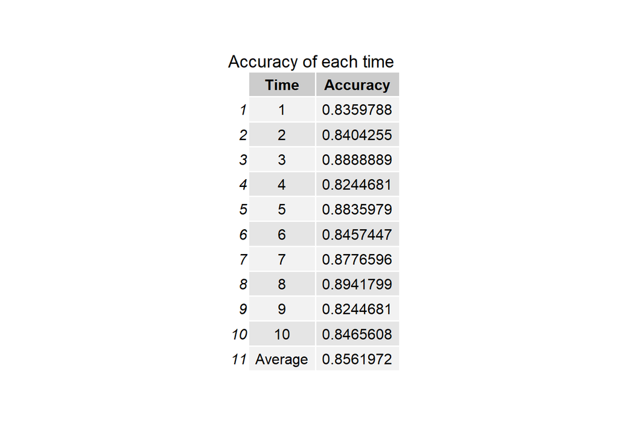

```r
accuracy_dt <- data.table(Time = c(1:10, "Average"),
                          Accuracy = c(accuracy_list, avg_accuracy))

table <- tableGrob(accuracy_dt)

tt <- textGrob(" Accuracy of each time",gp=gpar(fontsize=14))
fn <- textGrob("", x=0, hjust=0,
                     gp=gpar( fontface="italic"))

padding <- unit(0.5,"line")
table <- gtable_add_rows(table,
                         heights = grobHeight(tt) + padding,
                         pos = 0)
table <- gtable_add_rows(table, heights = grobHeight(fn)+ padding)
table <- gtable_add_grob(table, list(tt, fn),t=c(1, nrow(table)), l=c(1,2), r=ncol(table))
grid.newpage()
grid.draw(table)
```

0.86 is the accuracy I would see if there is a new dataset.

# Question 3

## 3.1

For this task, I split the data to 80% train(cross-validation) data for hyperparameter tuning, and 20% testing data for computing the accuracy.

I will use three models on train data:

1. KNN
2. Random Forest
3. SVM

For each of these models, I tune the hyperparameter respectively：

1. “K” in KNN
2. ”Number of trees" in Random Forest
3. “Kernel” in SVM

I choose the hyperparameter value with highest accuracy based on cross-validation accuracy.

Finally, I use these models to predict the test data, and ensemble the three predictions with majority vote.

#### Data preparation

```r
# train-cvdata 80%
# test 20%

#Create train, test data and use them for all three training methods.
new3druguse <- newdruguse[sample(nrow(newdruguse)), c(1:16,33)] #shuffle the data
#Note that here newdruguse already has all the entries in numbers.
tr <- new3druguse[1:round(0.8*nrow(new3druguse)),]
te <- new3druguse[round(0.8*nrow(new3druguse)+1):nrow(new3druguse),]
```

#### Data scaling

KNN and SVM uses distance in their algorithm and scaling the train and test data usually improves the accuracy. Also, scaling will not affect the random forest.

```r
scaletrain <- scale(tr[, 1:16]); scaletest <- scale(te[, 1:16])
train <- as.data.frame(scaletrain)
train$UseLevel <- tr$UseLevel
test <- as.data.frame(scaletest)
test$UseLevel <- te$UseLevel
```

#### KNN

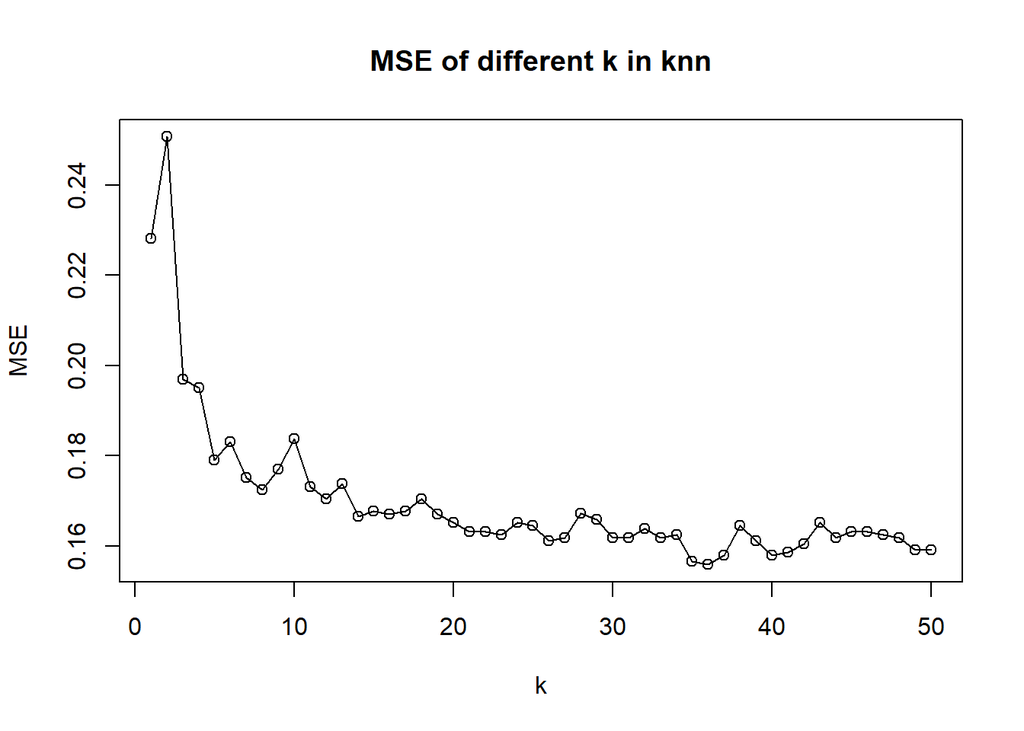

```r
folds <- cut(seq(1,nrow(train)),breaks=10,labels=FALSE)
#We use cross-validation on train data and also tune the hyperparameter k based on averaged MSE.
mse_for_k_list <- c() #list of average MSE of different k in knn
for(k in 1:50){
  cv_mse_list <- c() #list of MSEs of cross validation when one block is left out
  for(i in 1:10){#10-fold CV
    #Segement train data by fold
    testIndexes <- which(folds==i,arr.ind=TRUE)
    cv_test <- train[testIndexes, -17]
    cv_test_observe <- train[testIndexes, 17]
    cv_train <- train[-testIndexes, -17]
    cv_train_observe <- train[-testIndexes, 17]
    cv_predict <- knn(cv_train, cv_test, cv_train_observe, k = k)
    cv_mse <- sum(cv_predict != cv_test_observe)/length(cv_predict)
    cv_mse_list <- c(cv_mse_list, cv_mse)
  }
  mse_for_k <- sum(cv_mse_list)/10
  mse_for_k_list <- c(mse_for_k_list, mse_for_k)
}

plot(1:50, mse_for_k_list,
     type = "o",
     main = "MSE of different k in knn",
     xlab = "k", ylab = "MSE")
```

```r
my_k <- which(mse_for_k_list == min(mse_for_k_list)) # we choose the k that minimises the MSE
my_k
```

```
## [1] 36
```

```r
knn_predict <- knn(train[,-17], test[,-17], train[,17], k = my_k) # Use the model to predict testing data
```

#### RandomForest

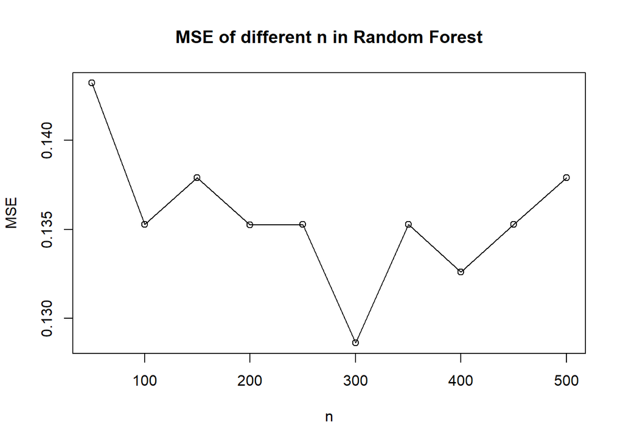

```r
train$UseLevel <- as.character(train$UseLevel)#Convert the data to factor to tell the model use classification
train$UseLevel <- as.factor(train$UseLevel)

mse_for_n_list <- c() #list of average MSE of different n(number of trees) in random forest
for(n in seq(50,500,by=50)){
  cv_mse_list <- c() #list of MSEs of cross validation when one block is left out
  for(i in 1:5){   #perfom 5-fold CV
    #Segement data by fold and train, predict
    testIndexes <- which(folds==i,arr.ind=TRUE)
    cv_test <- train[testIndexes, ]
    cv_train <- train[-testIndexes, ]
    rf <- randomForest(UseLevel ~ ., data = cv_train, ntree = n, mtry = sqrt(16))
    cv_rf_predict <- predict(rf, cv_test, type="response")
    cv_mse <- sum(cv_rf_predict != cv_test[,17])/length(cv_rf_predict)
    cv_mse_list <- c(cv_mse_list, cv_mse)
  }
  mse_for_n <- sum(cv_mse_list)/5
  mse_for_n_list <- c(mse_for_n_list, mse_for_n)
}
# plot MSE of different n in Random Forest
plot(seq(50,500,by=50), mse_for_n_list,
     type = "o",
     main = "MSE of different n in Random Forest",
     xlab = "n", ylab = "MSE")
```

```r
nth_inlist <- which(mse_for_n_list == min(mse_for_n_list))
my_n <- seq(50,500,by=50)[nth_inlist]# we choose the n that minimises the MSE

rf <- randomForest(UseLevel ~ ., data = train, ntree = my_n, mtry = sqrt(16))
rf_predict <- predict(rf, test, type="response") # Use the model to predict testing data
```

#### SVM

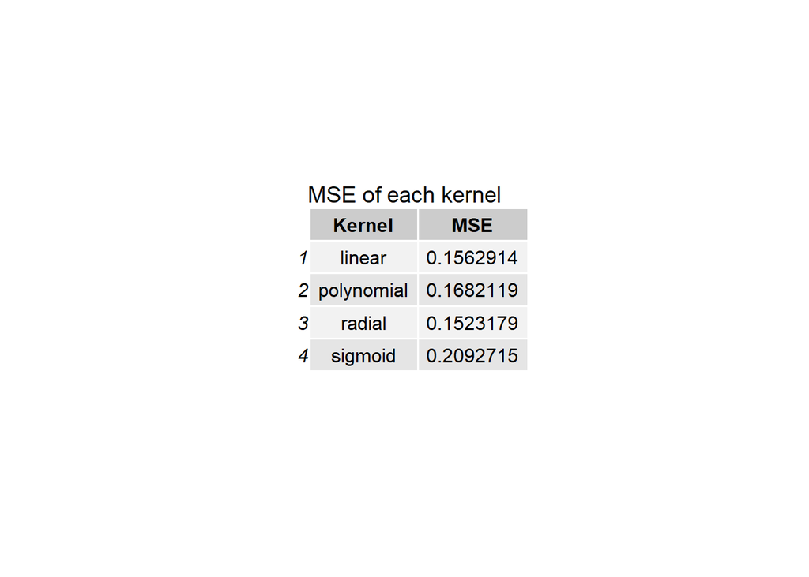

```r
mse_for_n_list <- c() #list of average MSE of different n(number of trees) in random forest
kernels <- c("linear", "polynomial", "radial", "sigmoid")
for(k in kernels){
  cv_mse_list <- c() #list of MSEs of cross validation when one block is left out
  for(i in 1:5){   #perfom 5-fold CV
    #Segement data by fold and train, predict
    testIndexes <- which(folds==i,arr.ind=TRUE)
    cv_test <- train[testIndexes, ]
    cv_train <- train[-testIndexes, ]
    cv_svm <- svm(formula = UseLevel~., data = cv_train, kernel = k)
    cv_svm_predict <- predict(cv_svm, cv_test, kernal = k)
    cv_mse <- sum(cv_svm_predict != cv_test[,17])/length(cv_rf_predict)
    cv_mse_list <- c(cv_mse_list, cv_mse)
  }
  mse_for_n <- sum(cv_mse_list)/5
  mse_for_n_list <- c(mse_for_n_list, mse_for_n)
}

nth_inkernels <- which(mse_for_n_list == min(mse_for_n_list))
my_kernel <- kernels[nth_inkernels]# we choose the kernel that minimises the MSE

# create table
mse_dt <- data.table(
  Kernel = kernels,
  MSE = mse_for_n_list
)

# Create table: MSE of each kernel
table <- tableGrob(mse_dt)

tt <- textGrob("MSE of each kernel",gp=gpar(fontsize=14))
fn <- textGrob("", x=0, hjust=0,
                     gp=gpar( fontface="italic"))

padding <- unit(0.5,"line")
table <- gtable_add_rows(table,
                         heights = grobHeight(tt) + padding,
                         pos = 0)
table <- gtable_add_rows(table, heights = grobHeight(fn)+ padding)
table <- gtable_add_grob(table, list(tt, fn),t=c(1, nrow(table)), l=c(1,2), r=ncol(table))
grid.newpage()
grid.draw(table)
grid.newpage()
grid.draw(table)
```

```r
svm <- svm(formula = UseLevel~., data = train, kernal = my_kernel)
svm_predict <- predict(svm, test, kernal = my_kernel)# Use the model to predict testing data
```

#### Ensemble with majority vote

```r
final_predict <- c()#Create a list of predictions
for (i in 1:length(svm_predict)){
  predicts_i <- c(knn_predict[i], rf_predict[i], svm_predict[i])
  mojority_i <- as.numeric(names(which.max(table(predicts_i))))#majority vote
  final_predict <- c(final_predict, mojority_i)#append new prediction to list
}
```

## 3.2

### Create table

The levels of final_predict and uselevel in test are both 1 and 2, where 1 represents low and 2 represents high.

```r
TP <- sum(final_predict==2 & test[, 17] == 2)
FP <- sum(final_predict==2 & test[, 17] == 1)
TN <- sum(final_predict==1 & test[, 17] == 1)
FN <- sum(final_predict==1 & test[, 17] == 2)
tablematrix <- matrix(data = c(TP,FN,FP,TN), nrow = 2, ncol = 2,
                      dimnames = list(c("high","low"),c("high","low")))
names(dimnames(tablematrix)) <- c("predicted","observed")
tablematrix
```

```
##          observed
## predicted high low
##      high  194  27
##      low    28 128
```

### Accuracy

```r
accuracy <- sum(c(final_predict) == test[, 17])/nrow(test)
accuracy
```

```
## [1] 0.8541114
```

The accuracy is high, suggesting that this is a good classifier

I split the data to 80% training (cross-validation) data for hyperparameter tuning, and 20% testing data for computing the accuracy.

The testing data has never used in training or hyperparameter tuning with cross validation.

After traning the models using training set, models are then used to predict the testing data, and accuracy on obeservations that are not in the training set are estimated.

# Question 4

## 4.1

```r
new4druguse <- druguse[, -c(31,32,33)]
new4druguse$everuseH <- ifelse(new4druguse$heroin > 0, "yes", "no")

new4druguse$everuseH <- as.character(new4druguse$everuseH)
new4druguse$everuseH <- as.factor(new4druguse$everuseH) #Convert the data to factor to tell the model use classification
```

**The question does not specifically say to exclude “heroin” for this model.**

However, If we do not exclude heroin, then every tree that has “heroin” on its split will be a perfect classifier. Hence 0 MSE and 100% accuracy on the random forest model, and it is meaningless.

This shows what will happen if we include heroin:

```r
rf_with_heroin <- randomForest(everuseH ~ ., data = new4druguse[1:1400,], ntree = 200, importance = TRUE, mtry = round(sqrt(30)))
rf_with_heroin
```

```
##
## Call:
##  randomForest(formula = everuseH ~ ., data = new4druguse[1:1400,      ], ntree = 200, importance = TRUE, mtry = round(sqrt(30)))
##                Type of random forest: classification
##                      Number of trees: 200
## No. of variables tried at each split: 5
##
##         OOB estimate of  error rate: 0.07%
## Confusion matrix:
##       no yes class.error
## no  1200   0       0.000
## yes    1 199       0.005
```

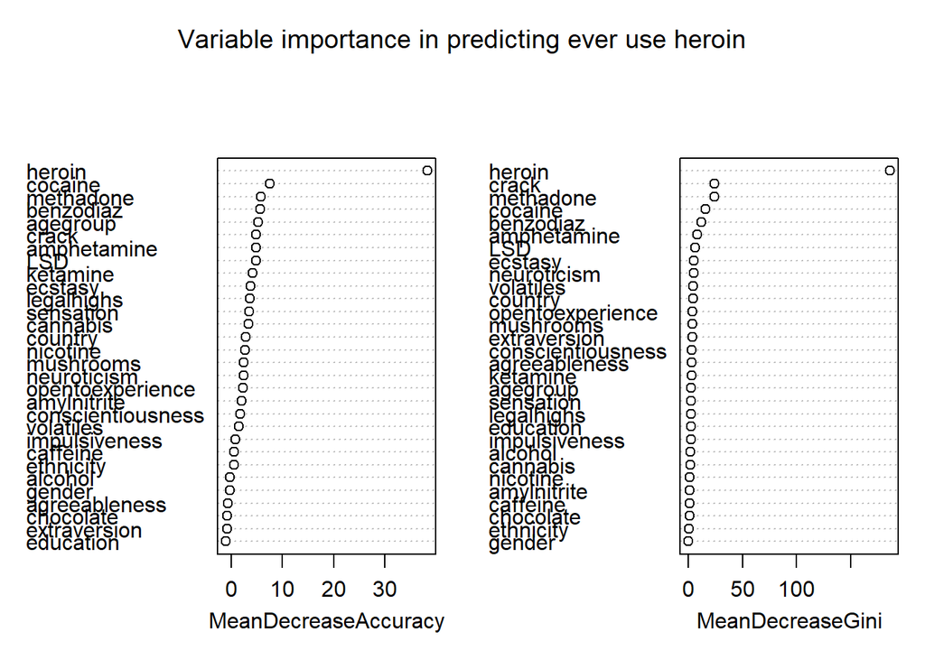

```r
varImpPlot(rf_with_heroin, main = "Variable importance in predicting ever use heroin")
```

From the summary, we could see there is an 100% accuracy.

From the graph, we could see heroin is a dominant predictor, far more important than other predictors.

**Hence, we exclude heroin to actually “predict” the everuseH**

Again, I use the first 1400 rows to train the model, and choose the n(number of trees) that minimizes MSE:

```r
new4druguse <- new4druguse[, -24] #exclude the heroin feature

train <- new4druguse[1:1400, ]
test <- new4druguse[1401:nrow(new4druguse), ]


mse_for_n_list <- c() #list of average MSE of different n(number of trees) in random forest
for(n in seq(50,500,by=50)){
  cv_mse_list <- c() #list of MSEs of cross validation when one block is left out
  for(i in 1:5){   #perfom 5-fold CV
    #Segement data by fold and train, predict
    testIndexes <- which(folds==i,arr.ind=TRUE)
    cv_test <- train[testIndexes, ]
    cv_train <- train[-testIndexes, ]
    rf <- randomForest(everuseH ~ ., data = cv_train, ntree = n, importance = TRUE, mtry = round(sqrt(29)))
    cv_rf_predict <- predict(rf, cv_test, type="response")
    cv_mse <- sum(cv_rf_predict != cv_test[,30])/length(cv_rf_predict)
    cv_mse_list <- c(cv_mse_list, cv_mse)
  }
  mse_for_n <- sum(cv_mse_list)/5
  mse_for_n_list <- c(mse_for_n_list, mse_for_n)
}
```

#### plot MSE of different n in Random Forest:

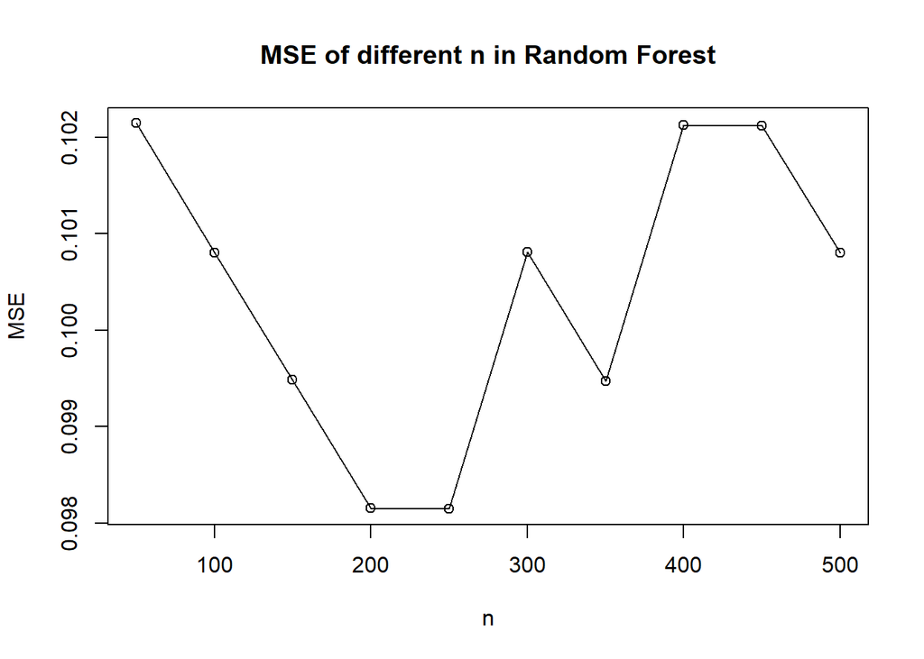

```r
plot(seq(50,500,by=50), mse_for_n_list,
     type = "o",
     main = "MSE of different n in Random Forest",
     xlab = "n", ylab = "MSE")
```

```r
nth_inlist <- which(mse_for_n_list == min(mse_for_n_list))
my_n <- seq(50,500,by=50)[nth_inlist]# we choose the n that minimises the MSE

rf <- randomForest(everuseH ~ ., data = train, ntree = my_n, mtry = round(sqrt(29)))
rf_predict <- predict(rf, test, type="response")
```

#### Create table and compute accuracy:

```r
#Create table
TP <- sum(rf_predict== "yes" & test[, 30] == "yes")
FP <- sum(rf_predict== "yes" & test[, 30] == "no")
TN <- sum(rf_predict== "no" & test[, 30] == "no")
FN <- sum(rf_predict== "no" & test[, 30] == "yes")
tablematrix <- matrix(data = c(TP,FN,FP,TN), nrow = 2, ncol = 2,
                      dimnames = list(c("Yes","No"),c("Yes","No")))
names(dimnames(tablematrix)) <- c("predicted","observed")
tablematrix
```

```
##          observed
## predicted Yes  No
##       Yes  43   6
##       No   37 399
```

```r
#Accuracy and other metrics
specificity <- TN/(TN+FP)
print(paste("specificity: ", specificity))
```

```
## [1] "specificity:  0.985185185185185"
```

```r
sensitivity <- TP/(TP+FN)
print(paste("sensitivity: ", sensitivity))
```

```
## [1] "sensitivity:  0.5375"
```

```r
accuracy <- sum(rf_predict == test[, 30])/nrow(test)
print(paste("accuracy ", accuracy))
```

```
## [1] "accuracy  0.911340206185567"
```

This is a high accuracy, suggesting that this is a good classifier in general. However, sensitivity is only 0.5375, this classifier is weak on classifying the actrual true everuseH.

## 4.2

From the heatmap in EDA, I saw a relatively strong correlation between nicotine and predictors like personality traits and background.

I will predict whether the individual is a regular smoker(who used nicotine last day) given individual’s background and personality traits.

For this task, I will use the same method as the one in **3.1**:

I split the data to 80% train(cross-validation) data for hyperparameter tuning, and 20% testing data for computing the accuracy.

I will use three models on train data:

1. KNN
2. Random Forest
3. SVM

For each of these models, I tune the hyperparameter respectively：

1. “K” in KNN
2. “Number of trees” in Random Forest
3. “Kernel” in SVM

I choose the hyperparameter value with highest accuracy based on cross-validation accuracy.

Finally, I use these models to predict the test data, and ensemble the three predictions with majority vote.

The reason that I choose these three models is because they are all good methods for classification, and when I ensemble them with majority voting, it could produce better predictions compared to a single model. If any one of the three models does not perform well or overfit the data, then it may be fixed by majority voting.

#### Data preparing

```r
delete <- c(13,14,16:33)
nicotineuse <- newdruguse[,-delete]
nicotineuse$nlastday <- ifelse(nicotineuse$nicotine == 6, 1, 0)
nicotineuse <- nicotineuse[,-13]

# train-cvdata 80%
# test 20%

#Create train, test data and use them for all three training methods.
nicotineuse <- nicotineuse[sample(nrow(nicotineuse)),] #shuffle the data
tr <- nicotineuse[1:round(0.8*nrow(nicotineuse)),]
te <- nicotineuse[round(0.8*nrow(nicotineuse)+1):nrow(nicotineuse),]
```

#### Data scaling

KNN and SVM uses distance in their algorithm so we scale the train and test data, and scaling will not affect the random forest.

```r
scaletrain <- scale(tr[, 1:12]); scaletest <- scale(te[, 1:12])
train <- as.data.frame(scaletrain)
train$nlastday <- tr$nlastday
test <- as.data.frame(scaletest)
test$nlastday <- te$nlastday
```

#### KNN

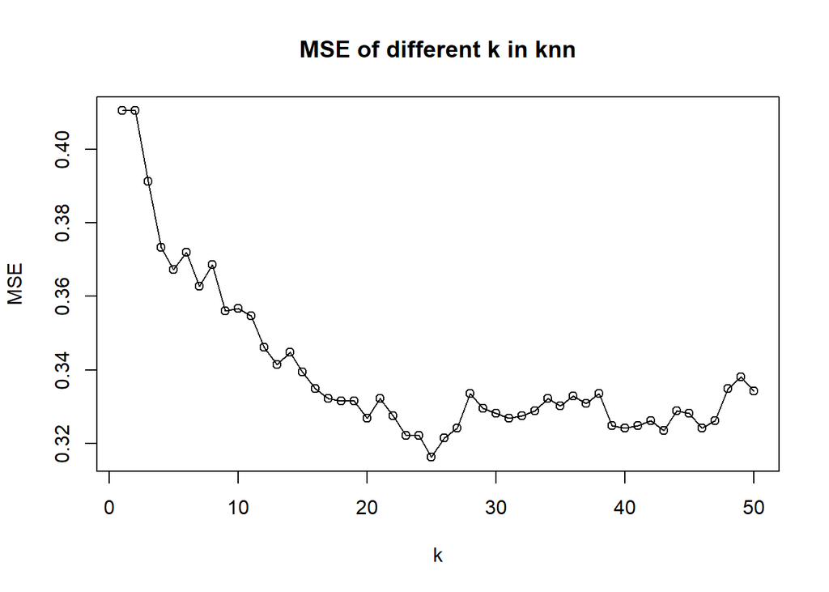

```r
folds <- cut(seq(1,nrow(train)),breaks=10,labels=FALSE)
#We use cross-validation on train data and also tune the hyperparameter k based on averaged MSE.
mse_for_k_list <- c() #list of average MSE of different k in knn
for(k in 1:50){
  cv_mse_list <- c() #list of MSEs of cross validation when one block is left out
  for(i in 1:10){
    #Segement train data by fold
    testIndexes <- which(folds==i,arr.ind=TRUE)
    cv_test <- train[testIndexes, -13]
    cv_test_observe <- train[testIndexes, 13]
    cv_train <- train[-testIndexes, -13]
    cv_train_observe <- train[-testIndexes, 13]
    cv_predict <- knn(cv_train, cv_test, cv_train_observe, k = k)
    cv_mse <- sum(cv_predict != cv_test_observe)/length(cv_predict)
    cv_mse_list <- c(cv_mse_list, cv_mse)
  }
  mse_for_k <- sum(cv_mse_list)/10
  mse_for_k_list <- c(mse_for_k_list, mse_for_k)
}
plot(1:50, mse_for_k_list,
     type = "o",
     main = "MSE of different k in knn",
     xlab = "k", ylab = "MSE")
```

```r
my_k <- which(mse_for_k_list == min(mse_for_k_list)) # we choose the k that minimises the MSE
my_k
```

```
## [1] 25
```

```r
knn_predict <- knn(train[,-13], test[,-13], train[,13], k = my_k)
```

#### RandomForest

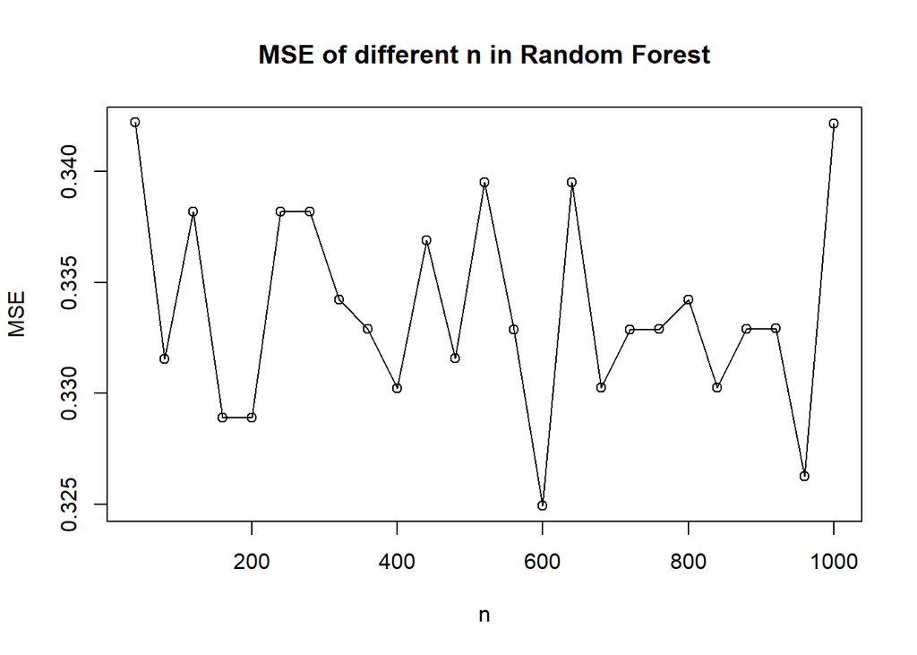

```r
train$nlastday <- as.character(train$nlastday)#Convert the data to factor to tell the model use classification
train$nlastday <- as.factor(train$nlastday)

mse_for_n_list <- c() #list of average MSE of different n(number of trees) in random forest
for(n in seq(40,1000,by=40)){
  cv_mse_list <- c() #list of MSEs of cross validation when one block is left out
  for(i in 1:5){   #perfom 5-fold CV
    #Segement data by fold and train, predict
    testIndexes <- which(folds==i,arr.ind=TRUE)
    cv_test <- train[testIndexes, ]
    cv_train <- train[-testIndexes, ]
    rf <- randomForest(nlastday ~ ., data = cv_train, ntree = n, mtry = sqrt(12))
    cv_rf_predict <- predict(rf, cv_test, type="response")
    cv_mse <- sum(cv_rf_predict != cv_test[,13])/length(cv_rf_predict)
    cv_mse_list <- c(cv_mse_list, cv_mse)
  }
  mse_for_n <- sum(cv_mse_list)/5
  mse_for_n_list <- c(mse_for_n_list, mse_for_n)
}
# plot MSE of different n in Random Forest
plot(seq(40,1000,by=40), mse_for_n_list,
     type = "o",
     main = "MSE of different n in Random Forest",
     xlab = "n", ylab = "MSE")
```

```r
nth_inlist <- which(mse_for_n_list == min(mse_for_n_list))
my_n <- seq(40,1000, by=40)[nth_inlist]# we choose the n that minimises the MSE

rf <- randomForest(nlastday ~ ., data = train, ntree = my_n, mtry = sqrt(12))
rf_predict <- predict(rf, test, type="response")
```

#### SVM

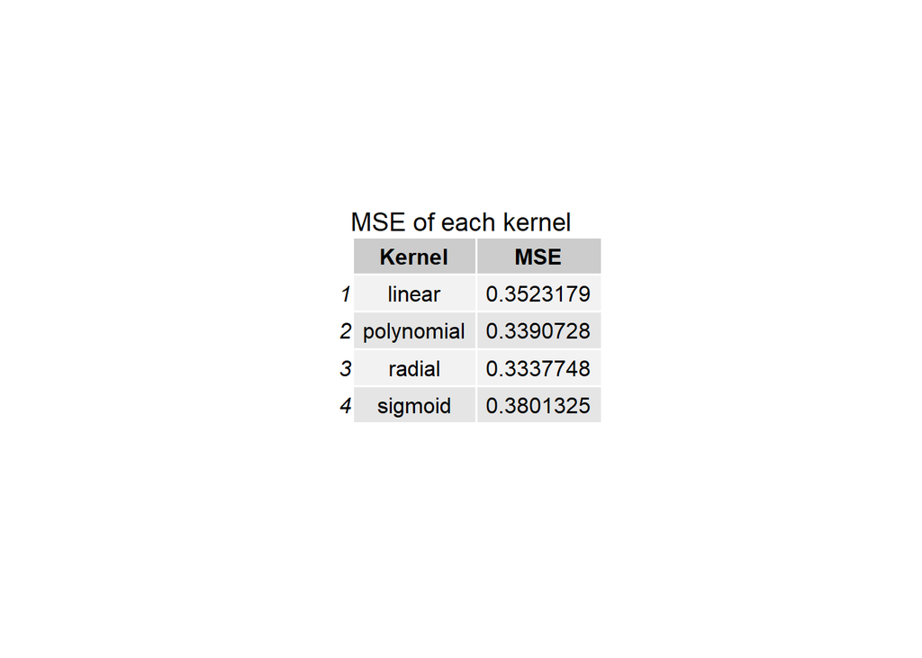

```r
mse_for_n_list <- c() #list of average MSE of different n(number of trees) in random forest
kernels <- c("linear", "polynomial", "radial", "sigmoid")
for(k in kernels){
  cv_mse_list <- c() #list of MSEs of cross validation when one block is left out
  for(i in 1:5){   #perfom 5-fold CV
    #Segement data by fold and train, predict
    testIndexes <- which(folds==i,arr.ind=TRUE)
    cv_test <- train[testIndexes, ]
    cv_train <- train[-testIndexes, ]
    cv_svm <- svm(formula = nlastday~., data = cv_train, kernel = k)
    cv_svm_predict <- predict(cv_svm, cv_test, kernal = k)
    cv_mse <- sum(cv_svm_predict != cv_test[,13])/length(cv_rf_predict)
    cv_mse_list <- c(cv_mse_list, cv_mse)
  }
  mse_for_n <- sum(cv_mse_list)/5
  mse_for_n_list <- c(mse_for_n_list, mse_for_n)
}

nth_inkernels <- which(mse_for_n_list == min(mse_for_n_list))
my_kernel <- kernels[nth_inkernels]# we choose the kernel that minimises the MSE

# create table
mse_dt <- data.table(
  Kernel = kernels,
  MSE = mse_for_n_list
)

# Create table: MSE of each kernel
table <- tableGrob(mse_dt)

tt <- textGrob("MSE of each kernel",gp=gpar(fontsize=14))
fn <- textGrob("", x=0, hjust=0,
                     gp=gpar( fontface="italic"))

padding <- unit(0.5,"line")
table <- gtable_add_rows(table,
                         heights = grobHeight(tt) + padding,
                         pos = 0)
table <- gtable_add_rows(table, heights = grobHeight(fn)+ padding)
table <- gtable_add_grob(table, list(tt, fn),t=c(1, nrow(table)), l=c(1,2), r=ncol(table))
grid.newpage()
grid.draw(table)
grid.newpage()
grid.draw(table)
```

```r
svm <- svm(formula = nlastday~., data = train, kernal = my_kernel)
svm_predict <- predict(svm, test, kernal = my_kernel)
```

#### Ensemble with majority vote

```r
final_predict <- c()#Create a list of predictions
for (i in 1:length(svm_predict)){
  predicts_i <- c(knn_predict[i], rf_predict[i], svm_predict[i])
  mojority_i <- as.numeric(names(which.max(table(predicts_i))))#majority vote
  final_predict <- c(final_predict, mojority_i)#append new prediction to list
}
final_predict <- final_predict -1 #The levels of final_predict are 1 and 2 due to the previous process.Change them to 0 and 1.
```

#### Create table

The levels of final_predict and nlastday in test are both 0 and 1, where 0 represents false and 1 represents true.

```r
TP <- sum(final_predict==1 & test[, 13] == 1)
FP <- sum(final_predict==1 & test[, 13] == 0)
TN <- sum(final_predict==0 & test[, 13] == 0)
FN <- sum(final_predict==0 & test[, 13] == 1)
tablematrix <- matrix(data = c(TP,FN,FP,TN), nrow = 2, ncol = 2,
                      dimnames = list(c("TRUE","FALSE"),c("TRUE","FALSE")))
names(dimnames(tablematrix)) <- c("predicted","observed")
tablematrix
```

```
##          observed
## predicted TRUE FALSE
##     TRUE    22    28
##     FALSE   89   238
```

#### Accuracy

```r
specificity <- TN/(TN+FP)
print(paste("specificity: ", specificity))
```

```
## [1] "specificity:  0.894736842105263"
```

```r
sensitivity <- TP/(TP+FN)
print(paste("sensitivity: ", sensitivity))
```

```
## [1] "sensitivity:  0.198198198198198"
```

```r
accuracy <- sum(final_predict == test[, 13])/nrow(test)
print(paste("accuracy: ", accuracy))
```

```
## [1] "accuracy:  0.689655172413793"
```

The table and metrics show that it is a relatively poor classification, with only 69% accuracy and 20% sensitiviy.

This is probably because predict just from the background and personality traits is not accurate enough, the consumption of other legal substances could be essential in predicting “nlastday”.

# Question 5

For this study, I will discuss the predictor importance in three aspects:

- New logistic regression summary (Here each predictor is not splited)
- Logistic regression summary in 2.1 (Here each predicotr is splited to different levels)
- Random forest variable importance plot

### New logistic regression summary

```r
new5druguse <- druguse[,c(1:16,33)]
new5druguse$gender <- as.numeric(factor(new5druguse$gender))
new5druguse$agegroup <- as.numeric(factor(new5druguse$agegroup))
new5druguse$country <- as.numeric(factor(new5druguse$country))
new5druguse$ethnicity <- as.numeric(factor(new5druguse$ethnicity))
new5druguse$UseLevel <- ifelse(new5druguse$UseLevel == "high", 1, 0)
model <- glm(UseLevel ~., family = binomial(link = 'logit'), data = new5druguse)
summary(model)
```

```
##
## Call:
## glm(formula = UseLevel ~ ., family = binomial(link = "logit"),
##     data = new5druguse)
##
## Deviance Residuals:
##     Min       1Q   Median       3Q      Max
## -3.0981  -0.5037   0.1590   0.5323   2.8232
##
## Coefficients:
##                   Estimate Std. Error z value Pr(>|z|)
## (Intercept)       -1.07917    0.74434  -1.450 0.147102
## agegroup          -0.41950    0.05668  -7.401 1.35e-13 ***
## gender             0.84249    0.14558   5.787 7.17e-09 ***
## education         -0.28216    0.07628  -3.699 0.000217 ***
## country           -0.02678    0.04975  -0.538 0.590416
## ethnicity          0.17704    0.07477   2.368 0.017888 *
## neuroticism       -0.04775    0.08422  -0.567 0.570768
## extraversion      -0.26499    0.08845  -2.996 0.002737 **
## opentoexperience   0.75954    0.08325   9.123  < 2e-16 ***
## agreeableness     -0.13206    0.07584  -1.741 0.081633 .
## conscientiousness -0.36727    0.08457  -4.343 1.41e-05 ***
## impulsiveness     -0.05294    0.09260  -0.572 0.567518
## sensation          0.77332    0.10500   7.365 1.77e-13 ***
## caffeine           0.08953    0.06532   1.371 0.170506
## chocolate         -0.20119    0.06195  -3.248 0.001163 **
## nicotine           0.45726    0.03078  14.855  < 2e-16 ***
## alcohol           -0.16921    0.05181  -3.266 0.001091 **
## ---
## Signif. codes:  0 '***' 0.001 '**' 0.01 '*' 0.05 '.' 0.1 ' ' 1
##
## (Dispersion parameter for binomial family taken to be 1)
##
##     Null deviance: 2594.6  on 1884  degrees of freedom
## Residual deviance: 1379.1  on 1868  degrees of freedom
## AIC: 1413.1
##
## Number of Fisher Scoring iterations: 5
```

We perform significance test on predictors with signifcance level of 5%. By comparing the p-values of predictors with 5%, we have enough evidence to say that agegroup, gender, education, ethnicity, extraversion, opentoexperience, conscientiousness, sensation, chocolate, nicotine and alcohol has association with the use level. We consider them as important predictors.

### Logistic regression summary in 2.1

```r
model <- glm(UseLevel ~., family = binomial(link = 'logit'), data = new2druguse)
summary(model)
```

```
##
## Call:
## glm(formula = UseLevel ~ ., family = binomial(link = "logit"),
##     data = new2druguse)
##
## Deviance Residuals:
##     Min       1Q   Median       3Q      Max
## -3.3579  -0.4009   0.1124   0.4474   2.8756
##
## Coefficients:
##                              Estimate Std. Error z value Pr(>|z|)
## (Intercept)                  -0.19629    0.95675  -0.205  0.83744
## agegroup25-34                 0.23443    0.21160   1.108  0.26790
## agegroup35-44                -0.20712    0.21675  -0.956  0.33927
## agegroup45-54                -0.68269    0.23876  -2.859  0.00424 **
## agegroup55-64                -1.08345    0.33252  -3.258  0.00112 **
## agegroup65+                 -16.69147  450.02775  -0.037  0.97041
## gendermale                    0.91906    0.15854   5.797 6.74e-09 ***
## education                    -0.22350    0.08371  -2.670  0.00759 **
## countryCanada                -1.06020    0.57581  -1.841  0.06559 .
## countryNewZealand            -0.64702    1.41818  -0.456  0.64822
## countryOther                 -1.39314    0.55855  -2.494  0.01262 *
## countryRepublicofIreland     -1.81361    0.83436  -2.174  0.02973 *
## countryUK                    -2.31981    0.48130  -4.820 1.44e-06 ***
## countryUSA                   -0.18407    0.50419  -0.365  0.71505
## ethnicityBlack               -0.39041    1.06744  -0.366  0.71455
## ethnicityMixed-Black/Asian   15.49469 1235.75528   0.013  0.99000
## ethnicityMixed-White/Asian    1.05209    1.08983   0.965  0.33436
## ethnicityMixed-White/Black    0.70634    1.02772   0.687  0.49190
## ethnicityOther                0.73069    0.83682   0.873  0.38257
## ethnicityWhite                1.19818    0.72990   1.642  0.10068
## neuroticism                  -0.04675    0.09043  -0.517  0.60519
## extraversion                 -0.09486    0.09524  -0.996  0.31926
## opentoexperience              0.55223    0.09134   6.046 1.49e-09 ***
## agreeableness                -0.05987    0.08220  -0.728  0.46644
## conscientiousness            -0.40745    0.08982  -4.536 5.73e-06 ***
## impulsiveness                -0.06932    0.09823  -0.706  0.48036
## sensation                     0.72495    0.11316   6.407 1.49e-10 ***
## caffeine                      0.07706    0.07028   1.097  0.27285
## chocolate                    -0.13457    0.06702  -2.008  0.04466 *
## nicotine                      0.47814    0.03355  14.253  < 2e-16 ***
## alcohol                      -0.11947    0.05685  -2.102  0.03558 *
## ---
## Signif. codes:  0 '***' 0.001 '**' 0.01 '*' 0.05 '.' 0.1 ' ' 1
##
## (Dispersion parameter for binomial family taken to be 1)
##
##     Null deviance: 2594.6  on 1884  degrees of freedom
## Residual deviance: 1221.9  on 1854  degrees of freedom
## AIC: 1283.9
##
## Number of Fisher Scoring iterations: 15
```

Again we perform the same test on this model with significance level of 5%, the predictors with more than one ’*’ are considered as important predictors.

### Random forest variable importance plot

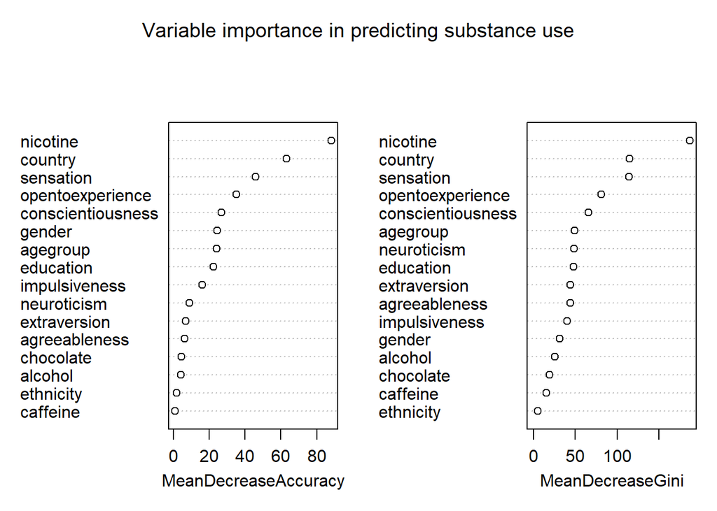

```r
new3druguse$UseLevel <- as.character(new3druguse$UseLevel)
new3druguse$UseLevel <- as.factor(new3druguse$UseLevel)
rf <- randomForest(UseLevel ~ ., data = new3druguse, importance = TRUE, ntree = my_n, mtry = sqrt(16))
varImpPlot(rf, main = "Variable importance in predicting substance use")
```

Mean decrease in accuracy and mean decrease gini are important index for variable importance. Variables with a large mean decrease in accuracy and mean decrease in Gini are more important for classification of the data. From the graph we can see that, nicotine, country, sensation, opentoexperience, conscientiousness, agegroup, gender, education, neuroticism are important predictors.

### Conclusion

Nicotine, sensation, opentoexperience, conscientiousness, agegroup, gender are considered as important predictors in all three aspects.